# Trust

# 1 Description of DataSchema variable

The description of harmonised variable is the following:

- Short name: `trust`
- Variable label: `Can people, generally speaking, be trusted?`
- Variable description: `Can people be trusted (generalized trust, i.e. trust in other members of the society, not counting relatives and close friends)?`
- Domain: `Social environment`
- Value type: `categorical`
- Category coding:

| **Code** | **Category Label** |
| --- | --- |
| 0 | No |
| 1 | Yes |

- Category missings:

| **Code** | **Category Label** |
| --- | --- |
| 991 | CAPI/interviewer error |
| 992 | Impute |
| 993 | Disable to measure |
| 994 | Not attempt/not done |
| 995 | Does not answer |
| 996 | Not applicable |
| 997 | Refuse |
| 998 | Do not know |
| 999 | Missing |

# 2 Data process

## 2.1 England

### 2.1.1 Wave 1

#### 2.1.1.1 Study-specific variable description

| **Name** | `scscd` |
| --- | --- |
| **Label** | `Most people in this area can be trusted/Most people in this area can't be trusted` |
| **Table name** | `wave_1_core_data_v3` |
| **Categories** | `1 = Most people in this area can be trusted` `2` `3` `4` `5` `6` `7 = Most people in this area can't be trusted` |
| **Missings** | `-9 = Not answered` `-1 = Item not applicable` |
| **Description** |  |

SCSCD

| Sample size | Missing values |
| --- | --- |
| 12099 | 1395 |

Category

|  | 1 | 2 | 3 | 4 | 5 | 6 | 7 |
| --- | --- | --- | --- | --- | --- | --- | --- |
| Frequency | 3691.00 | 2572.00 | 1555.00 | 1614.00 | 476.00 | 353.00 | 443.00 |
| Percentage | 30.51 | 21.26 | 12.85 | 13.34 | 3.93 | 2.92 | 3.66 |

Type of missing

|  | -9 | -1 | NA |
| --- | --- | --- | --- |
| Frequency | 287.00 | 1108.00 | 0 |
| Percentage | 2.37 | 9.16 | 0 |

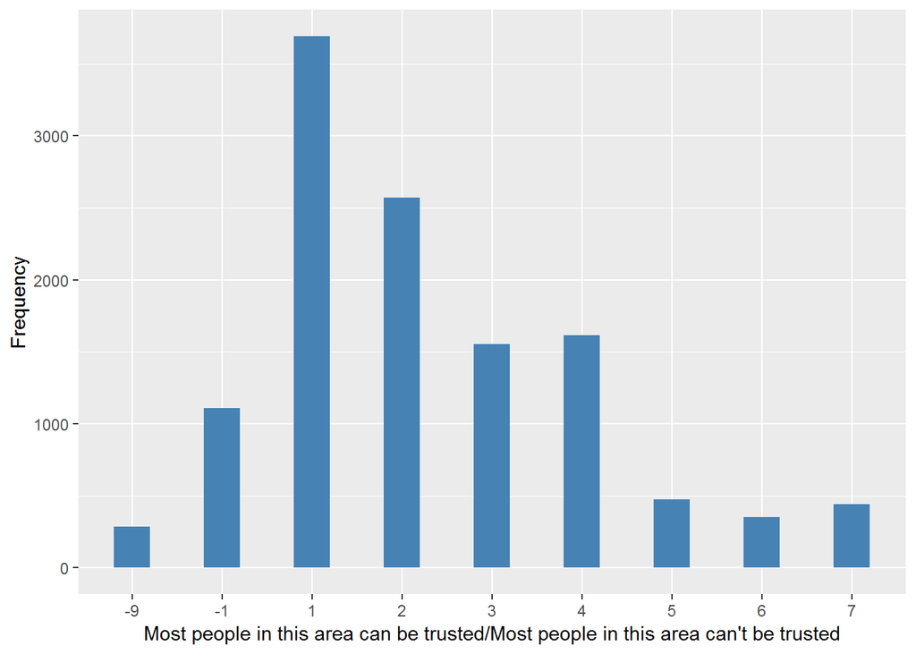

#### 2.1.1.2 Harmonisation algorithm

To compute the harmonize variable from the study-specific variable it has to be recoded as follows:

- `1,2,3 into 1`
- `4,5,6,7 into 0`
- `-9 into 995`
- `-1 into 996`
- `NA into 999`

**R script:**

```r
ELSA_ds_w1 <- tibble(id = ELSA_w1_trust$id)
ELSA_ds_w1$trust <- car::recode(as.vector(ELSA_w1_trust$scscd), "1:3='1'; 4:7='0'; -9='995'; -1='996'; NA='999'")
ELSA_ds_w1$trust <- labelled(ELSA_ds_w1$trust, labels = c(No = 0, Yes = 1, Missing = 999,
    `Do not know` = 998, Refuse = 997, `Not applicable` = 996, `Don't answer` = 995,
    `Not attempt/not done/not yet recorded` = 994, `Disable to measure` = 993,
    Impute = 992, `CAPI/interviewer error` = 991))
```

#### 2.1.1.3 Statistical description of the new harmonised variable

| Sample size | Missing values |
| --- | --- |
| 12099 | 1395 |

Category

|  | 0 | 1 |
| --- | --- | --- |
| Frequency | 2886.00 | 7818.00 |
| Percentage | 23.85 | 64.62 |

Type of missing

|  | 991 | 992 | 993 | 994 | 995 | 996 | 997 | 998 | 999 | NA |
| --- | --- | --- | --- | --- | --- | --- | --- | --- | --- | --- |
| Frequency | 0 | 0 | 0 | 0 | 287.00 | 1108.00 | 0 | 0 | 0 | 0 |
| Percentage | 0 | 0 | 0 | 0 | 2.37 | 9.16 | 0 | 0 | 0 | 0 |

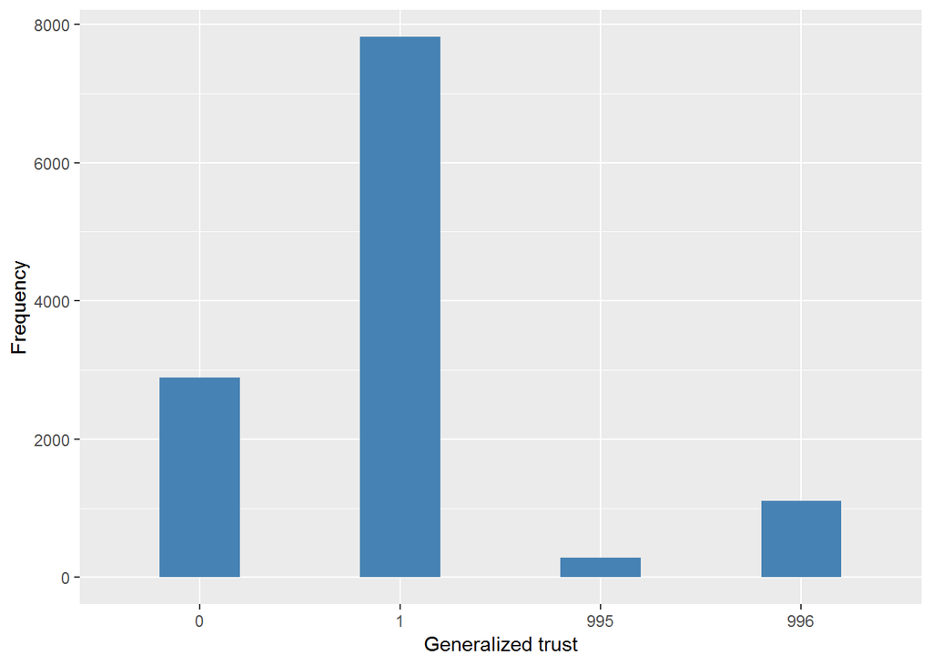

#### 2.1.1.4 Validation

|  | 4:7->0 | 1:3->1 | -9->995 | -1->996 |
| --- | --- | --- | --- | --- |
| BeforeH1 | 2886 | 7818 | 287 | 1108 |
| AfterH | 2886 | 7818 | 287 | 1108 |

### 2.1.2 Wave 2

Not found.

### 2.1.3 Wave 3

#### 2.1.3.1 Study-specific variable description

| **Name** | `scscd` |
| --- | --- |
| **Label** | `Most people in this area can be trusted/Most people in this area can't be trusted` |
| **Table name** | `wave_3_elsa_data_v4` |
| **Categories** | `1 = Strongly agree` `2 = Somewhat agree` `3 = Agree a little` `4 = Neither agree nor disagree` `5 = Disagree a little` `6 = Somewhat disagree` `7 = Strongly disagree` |
| **Missings** | `-9 = Not answered` `-8 = Don't know` `-1 = Item not applicable` |
| **Description** |  |

SCSCD

| Sample size | Missing values |
| --- | --- |
| 9771 | 1709 |

Category

|  | 1 | 2 | 3 | 4 | 5 | 6 | 7 |
| --- | --- | --- | --- | --- | --- | --- | --- |
| Frequency | 2826.00 | 2239.00 | 1002.00 | 1076.00 | 345.00 | 304.00 | 270.00 |
| Percentage | 28.92 | 22.91 | 10.25 | 11.01 | 3.53 | 3.11 | 2.76 |

Type of missing

|  | -9 | -8 | -1 | NA |
| --- | --- | --- | --- | --- |
| Frequency | 182.00 | 0 | 1527.00 | 0 |
| Percentage | 1.86 | 0 | 15.63 | 0 |

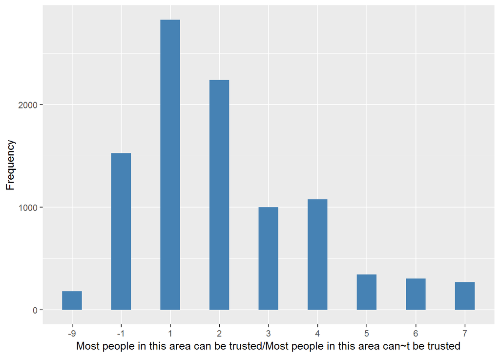

#### 2.1.3.2 Harmonisation algorithm

To compute the harmonize variable from the study-specific variable it has to be recoded as follows:

- `1,2,3 into 1`
- `4,5,6,7 into 0`
- `-9 into 995`
- `-8 into 998`
- `-1 into 996`
- `NA into 999`

**R script:**

```r
ELSA_ds_w3 <- tibble(id = ELSA_w3_trust$id)
ELSA_ds_w3$trust <- car::recode(as.vector(ELSA_w3_trust$scscd), "1:3='1'; 4:7='0'; -9='995'; -8='998'; -1='996'; NA='999'")
ELSA_ds_w3$trust <- labelled(ELSA_ds_w3$trust, labels = c(No = 0, Yes = 1, Missing = 999,
    `Do not know` = 998, Refuse = 997, `Not applicable` = 996, `Don't answer` = 995,
    `Not attempt/not done/not yet recorded` = 994, `Disable to measure` = 993,
    Impute = 992, `CAPI/interviewer error` = 991))
```

#### 2.1.3.3 Statistical description of the new harmonised variable

| Sample size | Missing values |
| --- | --- |
| 9771 | 1709 |

Category

|  | 0 | 1 |
| --- | --- | --- |
| Frequency | 1995.00 | 6067.00 |
| Percentage | 20.42 | 62.09 |

Type of missing

|  | 991 | 992 | 993 | 994 | 995 | 996 | 997 | 998 | 999 | NA |
| --- | --- | --- | --- | --- | --- | --- | --- | --- | --- | --- |
| Frequency | 0 | 0 | 0 | 0 | 182.00 | 1527.00 | 0 | 0 | 0 | 0 |
| Percentage | 0 | 0 | 0 | 0 | 1.86 | 15.63 | 0 | 0 | 0 | 0 |

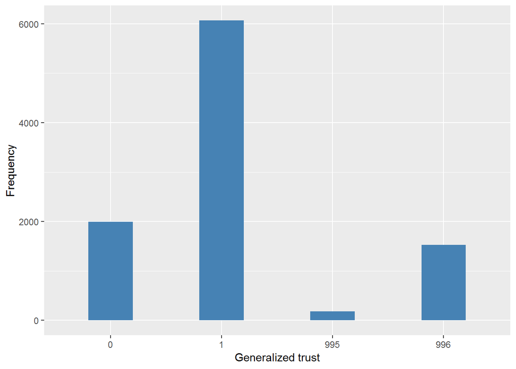

#### 2.1.3.4 Validation

|  | 4:7->0 | 1:3->1 | -9->995 | -1->996 |
| --- | --- | --- | --- | --- |
| BeforeH1 | 1995 | 6067 | 182 | 1527 |
| AfterH | 1995 | 6067 | 182 | 1527 |

### 2.1.4 Wave 4

Not found.

### 2.1.5 Wave 5

Not found.

### 2.1.6 Wave 6

Not found.

### 2.1.7 Wave 7

| **Name** | `scarea4` |
| --- | --- |
| **Label** | `Most people in this area can be trusted` |
| **Table name** | `wave_7_elsa_data` |
| **Categories** | `1 = Most people in this area can be trusted` `2` `3` `4` `5` `6` `7 = Most people in this area can't be trusted` |
| **Missings** | `-9 = Not answered` `-8 = Don't know` `-2 = Schedule not applicable` `-1 = Item not applicable` |
| **Description** |  |

scarea4

| Sample size | Missing values |
| --- | --- |
| 9666 | 1674 |

Category

|  | 1 | 2 | 3 | 4 | 5 | 6 | 7 |
| --- | --- | --- | --- | --- | --- | --- | --- |
| Frequency | 2626.00 | 2234.00 | 980.00 | 1028.00 | 405.00 | 423.00 | 296.00 |
| Percentage | 27.17 | 23.11 | 10.14 | 10.64 | 4.19 | 4.38 | 3.06 |

Type of missing

|  | -9 | -2 | -1 | NA |
| --- | --- | --- | --- | --- |
| Frequency | 205.00 | 1469.0 | 0 | 0 |
| Percentage | 2.12 | 15.2 | 0 | 0 |

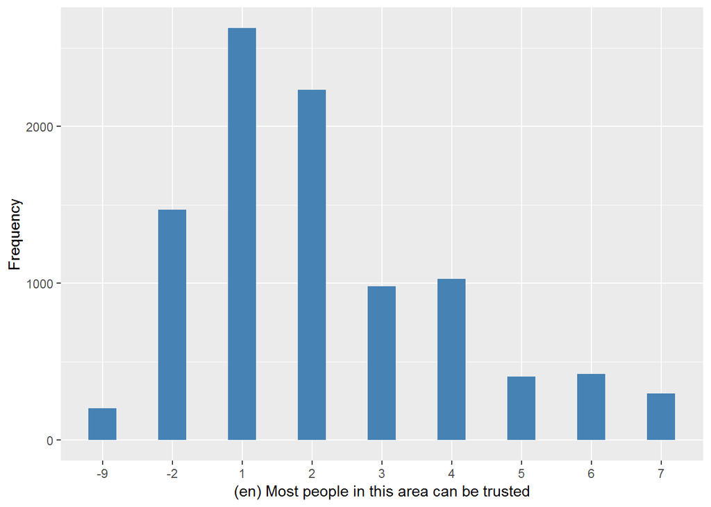

#### 2.1.7.1 Harmonisation algorithm

To compute the harmonize variable from the study-specific variable it has to be recoded as follows:

- `1,2,3 into 1`
- `4,5,6,7 into 0`
- `-9 into 995`
- `-8 into 998`
- `-1,-2 into 996`
- `NA into 999`

**R script:**

```r
ELSA_ds_w7 <- tibble(id = ELSA_w7$id)
ELSA_ds_w7$trust <- car::recode(as.vector(ELSA_w7$scarea4), "1:3='1'; 4:7='0'; -9='995'; -8='998'; -1='996'; -2 = 996; NA='999'")
```

#### 2.1.7.2 Statistical description of the new harmonised variable

Can people, generally speaking, be trusted?

| Sample size | Missing values |
| --- | --- |
| 9666 | 1674 |

Category

|  | 0 | 1 |
| --- | --- | --- |
| Frequency | 2152.00 | 5840.00 |
| Percentage | 22.26 | 60.42 |

Type of missing

|  | 991 | 992 | 993 | 994 | 995 | 996 | 997 | 998 | 999 | NA |
| --- | --- | --- | --- | --- | --- | --- | --- | --- | --- | --- |
| Frequency | 0 | 0 | 0 | 0 | 205.00 | 1469.0 | 0 | 0 | 0 | 0 |
| Percentage | 0 | 0 | 0 | 0 | 2.12 | 15.2 | 0 | 0 | 0 | 0 |

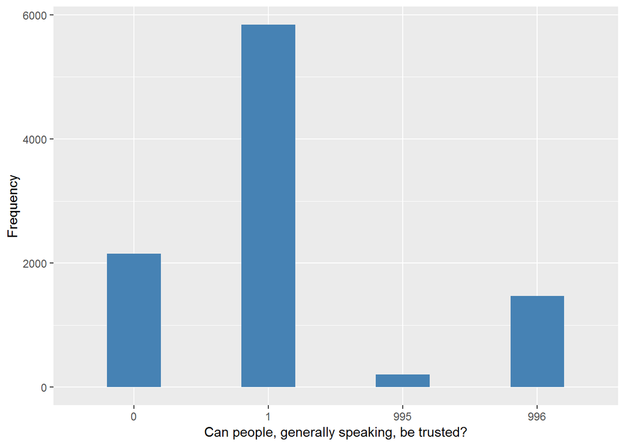

## 2.2 Summary of descriptive statistics of the harmonised variable accross populations and waves

Two tables are generated:

1. Percentages of categories in each harmonised variable.
2. Frequencies and percentages of individuals with different trajectories. To avoid too large table, Only trajectories with percentages larger than 0.3 are shown.

Can people, generally speaking, be trusted?

| val | label | W1 | W3 | W7 |
| --- | --- | --- | --- | --- |
| 0 | No | 23.85 | 20.42 | 22.26 |
| 1 | Yes | 64.62 | 62.09 | 60.42 |
| 991 | CAPI interviewer error | 0 | 0 | 0 |
| 992 | Impute | 0 | 0 | 0 |
| 993 | Disable to measure | 0 | 0 | 0 |
| 994 | Not attempt not done | 0 | 0 | 0 |
| 995 | Does not answer | 2.37 | 1.86 | 2.12 |
| 996 | Not applicable | 9.16 | 15.63 | 15.2 |
| 997 | Refuse | 0 | 0 | 0 |
| 998 | Do not know | 0 | 0 | 0 |
| 999 | Missing | 0 | 0 | 0 |
| NA | NA | 0 | 0 | 0 |
| n | sample size | 12099 | 9771 | 9666 |

| val | frq | raw.prc |
| --- | --- | --- |
| 000 | 208 | 1.20 |
| 001 | 203 | 1.17 |
| 00NA | 296 | 1.71 |
| 010 | 165 | 0.95 |
| 011 | 388 | 2.25 |
| 01NA | 432 | 2.50 |
| 0NA0 | 74 | 0.43 |
| 0NA1 | 74 | 0.43 |
| 0NANA | 1046 | 6.05 |
| 100 | 134 | 0.78 |
| 101 | 269 | 1.56 |
| 10NA | 354 | 2.05 |
| 110 | 351 | 2.03 |
| 111 | 1945 | 11.26 |
| 11NA | 1657 | 9.59 |
| 1NA0 | 85 | 0.49 |
| 1NA1 | 272 | 1.57 |
| 1NANA | 2751 | 15.92 |
| NA00 | 140 | 0.81 |
| NA01 | 129 | 0.75 |
| NA0NA | 262 | 1.52 |
| NA10 | 111 | 0.64 |
| NA11 | 484 | 2.80 |
| NA1NA | 534 | 3.09 |
| NANA0 | 884 | 5.12 |
| NANA1 | 2076 | 12.01 |
| NANANA | 1955 | 11.31 |

# 3 Quality estimation